## Human Activity Recognition

### Machine Learning Project

This written assignment answers the peer assessed element of the Practical Machine Learning module, part of Coursera’s Data Science Specialization offered by the John’s Hopkins Bloomburg school of public health. The data used for the assignment comes from http://groupware.les.inf.puc-rio.br/har and was originally used for research into whether machine learning could be used to predict how well an individual performs a weight lifting exercise compared to its formal specification.

I have assumed that the 2000 word limit applies to the text of the submission, not the R code and that the limit of 5 figures relates to charts and tables, not the output of R commands.

### Data Preparation

First, download the data and load it into R.

```r
## For training and test
data.supplied <- read.table(file = "http://d396qusza40orc.cloudfront.net/predmachlearn/pml-training.csv", sep=',',header=T, quote='"', na.strings = c("", NA))
## For prediction exercise
data.quiz <- read.table(file = "http://d396qusza40orc.cloudfront.net/predmachlearn/pml-testing.csv", sep=',', header=T, quote='"', na.strings = c("", NA))
```

A visual inspection of the raw data shows that there are a number of columns where almost all values are NA. The exception appears to be when the new_window column is set to “yes”. For these rows all columns are populated although some clearly have invalid values such as “#DIV/0!” which suggests the data was at some point in a spreadsheet application and has since been corrupted. The names of the columns that are mostly NA have prefixes such as “max”, “min”, “avg”, “skew”" etc. and appear to be summarised values for the rows above, i.e the current “window”. This assumption is supported by the original paper which names 17 of these summarised columns as the data used in the original trial. As the values in these columns are mostly NA and those that are not NA appear to be corrupted, and given the fact that none of these columns have values in the test set, I decided to remove all of them. Of the remaining columns the first seven appear to be too specific to the training set for them to generalise well to a prediction from a different sample. For example we would not want to build a prediction based upon the subject’s name or the time they did the exercise:

```r
## NA cols
colsToKeep <- names(data.supplied)[!is.na(data.supplied[1,])]
## First seven cols
colsToKeep <- colsToKeep[-c(1,2,3,4,5,6,7)]
data.supplied.clean <- subset(data.supplied, select = colsToKeep)

colsToKeep <- names(data.quiz)[!is.na(data.quiz[1,])]
colsToKeep <- colsToKeep[-c(1,2,3,4,5,6,7)]
data.quiz.clean <- subset(data.quiz, select = colsToKeep)
```

We now have a clean data set consisting of 52 numeric variables and one outcome across 19,622 observations. The next step is to split the data into training and test:

```r
options(width=150)
library(caret)
inTrain <- createDataPartition(y=data.supplied.clean$classe, p=.6, list=F)
training <- data.supplied.clean[inTrain,]
testing <- data.supplied.clean[-inTrain,]
```

### Exploratory Data Analysis

Next, we explore correlations between our variables by visualising those correlations between variables that are greater than +/- 0.75

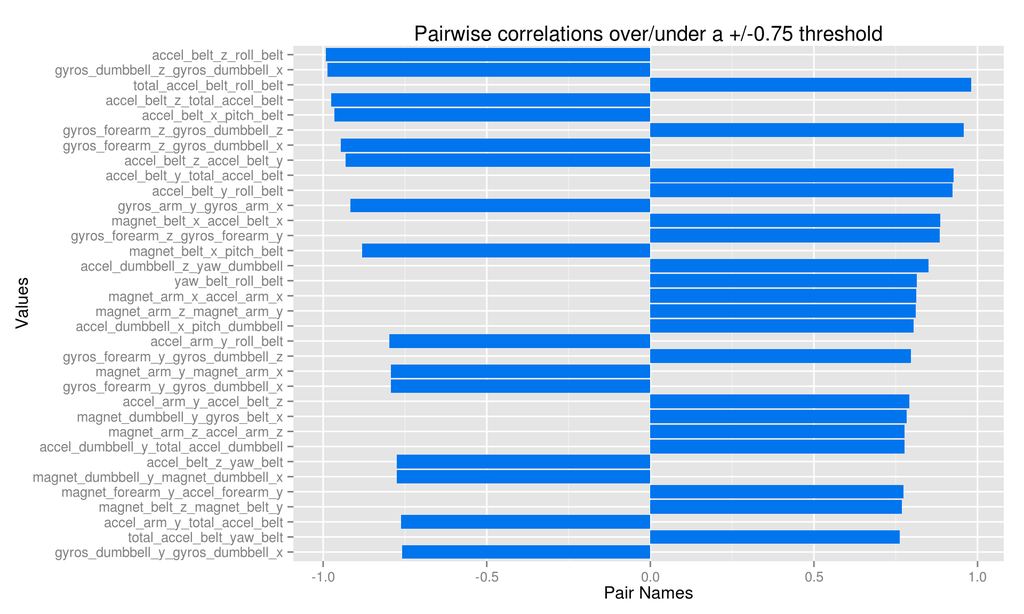

```r
## Get pairwise correlations and compute one side of diagonal
cordf <- as.data.frame(cor(training[-53]))
cordf[upper.tri(cordf)] <- NA
pairNames <-character()
values <- numeric()
## loop to find pairs over our .75 threshold
for(x in names(cordf))
{
  for(y in names(cordf))
  {
    if(x != y & !is.na(cordf[x,y]) &
        (
          (cordf[x,y] < 1 & cordf[x,y] >= 0.75) | (cordf[x,y] > -1 & cordf[x,y] <= -0.75)
        )
      ) {
      pairNames <- c(pairNames, paste0(x,"_",y))
      values <- c(values,cordf[x,y])
    }
  }
}

## plot it
library(ggplot2)
hiCorDf <- data.frame(pairNames, values)
hiCorDf <- hiCorDf[order(abs(hiCorDf$values), decreasing = T),]
hiCorDf$order <- seq(length(pairNames),1)
ggplot(hiCorDf) +
  geom_bar(aes(x = reorder(pairNames,order), y=values), stat="identity", position="identity", fill="#0075ee") + coord_flip() +
  ylab("Pair Names") + xlab("Values") +
  ggtitle("Pairwise correlations over/under a +/-0.75 threshold")
```

It appears that we have some strongly correlated variables so we may be able to reduce the complexity of our model by applying principle components analysis:

```r
pcaObj <- preProcess(training[, -53], method="pca", thresh=.8)
pcaObj
```

```
Call:
preProcess.default(x = training[, -53], method = "pca", thresh = 0.8)

Created from 11776 samples and 52 variables
Pre-processing: principal component signal extraction, scaled, centered

PCA needed 12 components to capture 80 percent of the variance
```

As we can get 80% of the variance from just 12 variables, there is a good case for applying pca to our data:

```r
set.seed(1234)

pcaTraining <- predict(pcaObj, training[, -53])
pcaTesting <- predict(pcaObj, testing[, -53])
pcaQuiz <- predict(pcaObj, data.quiz.clean[, -53])
```

We now have two data sets we can potentially use to train our model - a full set and a reduced pca set.

### Model Training

As this is a classification problem, there are a number of machine learning algorithms we could apply. I decided to try several models against both the full and PCA reduced data sets and to then compare them before choosing a final model. The families chosen were Decision Tree, Linear Discriminant Analysis and Random Forest.

For each model and each data set we add a model control to apply repeated cross validation with 10 folds repeated 5 times. We run the training in parallel and centre and scale the variables to normalise them.

```r
library(doMC)
numCores <- as.numeric(system("nproc", intern = T))

registerDoMC(cores = numCores)
```

```r
fitControl <- trainControl(
                           method = "repeatedcv",
                           number = 10,
                           repeats = 5,
                           allowParallel=T,
                           returnResamp = "final")

dataSources <- list("training" = training, "pca_training" = pcaTraining )
models <- c("rpart", "lda", "rf")
fits <- list()

for(model in models)
{
  for(dataSource in names(dataSources))
  {
     modFit<- train(training$classe ~ ., data = dataSources[[dataSource]], method = model, trControl=fitControl, preProc=c("center", "scale"))
     fits[[paste0(model,"_", dataSource)]] <- modFit
  }


}
```

### Model Evaluation and Comparison

We now have 6 models which we can use to predict outcomes. Before we do that, we check to see how well our models performed against the training data they were built upon by interrogating their resampling distributions:

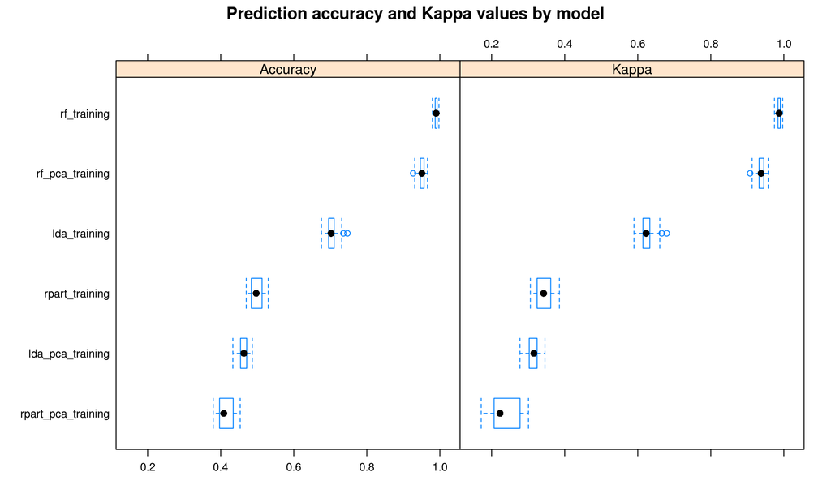

```r
resamp <- resamples(fits)
bwplot(resamp, main= "Prediction accuracy and Kappa values by model")
```

We can see that on the training data, Random Forrest out performed the rest based upon both accuracy and kappa values and generally models built on the PCA version of the training data appear not to do as well as those built on the full data set. For example the LDA model built on PCA data is outperformed by the classification tree model built on the full training set.

We can also examine if there is a significant statistical difference between the model types based upon the data that was used:

```r
resamp <- resamples(fits)
dif <- diff(resamp)
summary(dif)
```

```
Call:
summary.diff.resamples(object = dif)

p-value adjustment: bonferroni
Upper diagonal: estimates of the difference
Lower diagonal: p-value for H0: difference = 0

Accuracy
                   rpart_training rpart_pca_training lda_training lda_pca_training rf_training rf_pca_training
rpart_training                     0.0841            -0.2059       0.0360          -0.4914     -0.4520
rpart_pca_training < 2e-16                           -0.2900      -0.0481          -0.5756     -0.5362
lda_training       < 2e-16        < 2e-16                          0.2419          -0.2856     -0.2462
lda_pca_training   1.15e-14       < 2e-16            < 2e-16                       -0.5275     -0.4880
rf_training        < 2e-16        < 2e-16            < 2e-16      < 2e-16                       0.0394
rf_pca_training    < 2e-16        < 2e-16            < 2e-16      < 2e-16          < 2e-16

Kappa
                   rpart_training rpart_pca_training lda_training lda_pca_training rf_training rf_pca_training
rpart_training                     0.1052            -0.2819       0.0300          -0.6434     -0.5935
rpart_pca_training < 2e-16                           -0.3871      -0.0752          -0.7486     -0.6987
lda_training       < 2e-16        < 2e-16                          0.3118          -0.3615     -0.3116
lda_pca_training   1.68e-08       2.76e-15           < 2e-16                       -0.6733     -0.6235
rf_training        < 2e-16        < 2e-16            < 2e-16      < 2e-16                       0.0499
rf_pca_training    < 2e-16        < 2e-16            < 2e-16      < 2e-16          < 2e-16
```

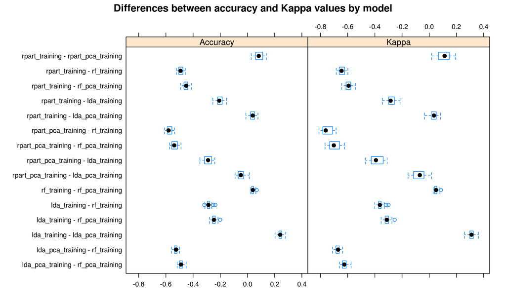

```r
bwplot(dif, , main= "Differences between accuracy and Kappa values by model")
```

We can see that the models are all significantly different from one another based upon the training data and that the biggest difference was between the Random Forest model built on the training data compared to the rpart model built on PCA data.

### Cross-validation

We now cross validate our models by applying them to our testing data to see how well they perform.

```r
## keep track of predictions agains quiz data while we are looping
predictions <- as.data.frame(data.quiz.clean$problem_id)
oose <- numeric()
for(model_data in names(fits))
{
        cat("---------------------------------------------------------------------------------\n",
        model_data, "\n",
        "---------------------------------------------------------------------------------\n", sep="")

  if(grepl(".*_pca.*", model_data)){
      #predict on pcaTesting data
      predObj <- predict(fits[[model_data]], pcaTesting)
      print(confusionMatrix(predObj, testing$classe))
      ## predict against quiz data while we are looping, used later
      predictions[model_data] <- predict(fits[[model_data]], pcaQuiz)
  }
  else
  {
      predObj <- predict(fits[[model_data]], testing)
      print(confusionMatrix(predObj, testing$classe))
      ## predict against quiz data while we are looping, used later
      predictions[model_data] <- predict(fits[[model_data]], data.quiz.clean)

  }
  ## calculate out of sample error based upon testing data
  oose <- c(oose,(OutOfSampleErrorPercent <- 100 * (1 - sum(predObj == testing$class)/length(predObj))))

}
```

```
---------------------------------------------------------------------------------
rpart_training
---------------------------------------------------------------------------------
Confusion Matrix and Statistics

          Reference
Prediction    A    B    C    D    E
         A 2041  652  689  569  206
         B   28  363   16  218   91
         C  157  503  663  499  493
         D    0    0    0    0    0
         E    6    0    0    0  652

Overall Statistics

               Accuracy : 0.474
                 95% CI : (0.463, 0.485)
    No Information Rate : 0.284
    P-Value [Acc > NIR] : <2e-16

                  Kappa : 0.312
 Mcnemar's Test P-Value : NA

Statistics by Class:

                     Class: A Class: B Class: C Class: D Class: E
Sensitivity             0.914   0.2391   0.4846    0.000   0.4521
Specificity             0.623   0.9442   0.7450    1.000   0.9991
Pos Pred Value          0.491   0.5070   0.2864      NaN   0.9909
Neg Pred Value          0.948   0.8380   0.8725    0.836   0.8901
Prevalence              0.284   0.1935   0.1744    0.164   0.1838
Detection Rate          0.260   0.0463   0.0845    0.000   0.0831
Detection Prevalence    0.530   0.0913   0.2951    0.000   0.0839
Balanced Accuracy       0.769   0.5917   0.6148    0.500   0.7256
---------------------------------------------------------------------------------
rpart_pca_training
---------------------------------------------------------------------------------
Confusion Matrix and Statistics

          Reference
```

[output cut: 149 more lines]

```

                  Kappa : 0.941
 Mcnemar's Test P-Value : 1.32e-10

Statistics by Class:

                     Class: A Class: B Class: C Class: D Class: E
Sensitivity             0.972    0.926    0.949    0.927    0.980
Specificity             0.987    0.990    0.974    0.992    0.997
Pos Pred Value          0.968    0.958    0.885    0.960    0.988
Neg Pred Value          0.989    0.982    0.989    0.986    0.995
Prevalence              0.284    0.193    0.174    0.164    0.184
Detection Rate          0.276    0.179    0.165    0.152    0.180
Detection Prevalence    0.286    0.187    0.187    0.158    0.182
Balanced Accuracy       0.979    0.958    0.961    0.960    0.989
```

We can see from the above that the Random Forest Model performs the best in terms of accuracy and kappa with values of 0.99 and 0.987 respectively. The rpart model using pca data was the worst performing combination (accuracy=0.402, kappa=0.199) and of particular note is its failure to predict outcomes for class C with a sensitivity of 0 and a specificity of 1.0.

### Predictions by model

We can compare the predictions against each of the 20 problem ids and tally up the votes for each class per model:

```r
names(predictions) <- c("problem_id", names(fits))
tpredictions <- as.data.frame(t(predictions[,-1]))
votes <- sapply(names(tpredictions), FUN=function(x){
  tbl <-table(tpredictions[,x])
  paste(names(tbl[tbl == max(tbl)]),  collapse = ",")
})
predictions$most_votes <- votes

library(knitr)
kable(predictions, "html", table.attr='class="flat-table"')
```

| problem_id | rpart_training | rpart_pca_training | lda_training | lda_pca_training | rf_training | rf_pca_training | most_votes |
| --- | --- | --- | --- | --- | --- | --- | --- |
| 1 | C | A | B | D | B | B | B |
| 2 | A | A | A | A | A | A | A |
| 3 | C | A | B | A | B | A | A |
| 4 | A | A | C | A | A | A | A |
| 5 | A | A | C | A | A | A | A |
| 6 | C | A | E | C | E | E | E |
| 7 | C | D | D | D | D | D | D |
| 8 | A | A | D | D | B | B | A,B,D |
| 9 | A | A | A | A | A | A | A |
| 10 | A | A | A | A | A | A | A |
| 11 | C | A | D | A | B | A | A |
| 12 | C | A | A | A | C | C | A,C |
| 13 | C | A | B | E | B | B | B |
| 14 | A | A | A | A | A | A | A |
| 15 | C | E | E | E | E | E | E |
| 16 | A | A | A | A | E | E | A |
| 17 | A | A | A | A | A | A | A |
| 18 | A | A | B | B | B | B | B |
| 19 | A | B | B | B | B | B | B |
| 20 | C | B | B | B | B | B | B |

We can also compare the out of sample error for each of the models by calculating the percentage of cases that the model predicted incorrectly for the testing data set:

```r
ooseDf <- as.data.frame(rbind(oose))
names(ooseDf) <- names(fits)
rownames(ooseDf) <- c("Out of sample error (%)")
kable(ooseDf, "html", table.attr='class="flat-table"')
```

|  | rpart_training | rpart_pca_training | lda_training | lda_pca_training | rf_training | rf_pca_training |
| --- | --- | --- | --- | --- | --- | --- |
| Out of sample error (%) | 52.6 | 59.76 | 30.17 | 52.85 | 1.045 | 4.69 |

### Final Model Selection

The model analysis above strongly suggests that the Random Forest model using the full training set is likely to give the most accurate results for predicting our 20 problem ids. This model was the one finally chosen for submission.